# Autoregressive Integrated Moving Average Process

Time Series

Description for Autoregressive Integrated Moving Average Process

Yeongeun Jeon , Jung In Seo  
2024-01-18

- **참고 : Statistics and Data Analysis for Financial Engineering**

# **1. 함수 설명**

- 관측된 시계열에 자기회귀누적이동평균모형(Autoregressive Integrated Moving Average Model)을 구축하는 데 유용한 함수를 요약하면 다음과 같다.

| 함수 | 설명 |
| --- | --- |
| `arima()` | ARIMA모형의 차수 $p$와 $q$, 차분 수 $d$를 지정하여 모형 구축 |
| `auto.arima()` | 모형의 차수 지정없이 자동적으로 최적화된 모형 구축 |
| `acf()` | 상관도표그림 |
| `pacf()` | 부분상관도표그림 |
| `Box.test()` | Ljung-Box Test |
| `checkresiduals()` | 잔차가 백색잡음과정의 가정을 만족하는지 확인할 때 사용 |
| `forecast()` | 예측 |

# **2. Random Walk and Momentum Plot**

```r
# AR(1)과정을 따르는 시계열 생성
set.seed(4631)
y1 <- arima.sim(n = 500,                 # 생성하고자하는 시계열 개수
               list(ar = c(0.4)))        # AR(1)과정 : Y_t = 0.4Y_{t-1}
y1
```

```
Time Series:
Start = 1
End = 500
Frequency = 1
  [1] -0.912343409 -1.701603284  1.309603454  0.691301009  0.832229499
  [6]  0.555481039 -0.026684342 -0.362545410  0.693315964 -0.075195230
 [11]  0.122254548 -0.370393783 -0.254577654  0.187517312 -1.708057556
 [16]  0.986697733 -0.640294098 -0.885591883 -0.993104578 -0.135172972
 [21] -0.194449428 -0.123467230 -1.216275158 -0.931739467  0.031253153
 [26] -1.499635290  1.319634259  2.398330132 -0.229766437  1.332681837
 [31]  0.157756638 -0.103097574 -0.102247983  2.536262232  3.218027097
 [36]  0.445937187 -0.177490207 -1.602786627 -0.913088486 -1.406607759
 [41]  0.099831368 -1.448052841  0.277834307  0.308540220  0.604106907
 [46]  0.372668105  1.287859364  1.821393863  3.624531543  0.972845982
 [51] -0.896416641 -1.777569846 -0.695491554 -1.375497500  1.007413097
```

[output cut: 89 more lines]

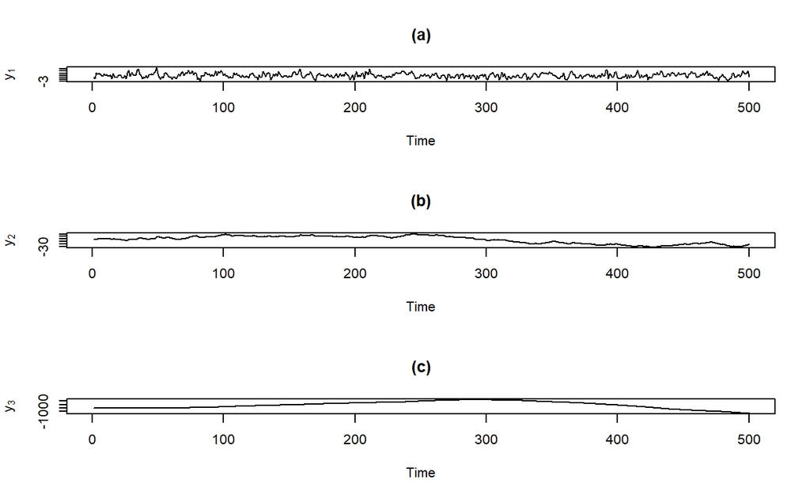

```r
y2 <- cumsum(y1)                         # cumsum : 누적합
y3 <- cumsum(y2)

par(mfrow=c(3, 1))                       # 3개의 그래프를 한 화면에 출력
plot(y1, type = "l",
     ylab = expression(y[1]),
     lwd = 1, main = "(a)")
plot(y2, type = "l",
     xlab = "Time", ylab = expression(y[2]),
     lwd = 1, main = "(b)")
plot(y3, type = "l",
     xlab = "Time", ylab = expression(y[3]),
     lwd = 1, main = "(c)")
```

`Result!` (a) 그래프는 평균 0 근처에서 무작위로 변하며, 정상시계열로 보인다.  
(b) 그래프는 Random Walk로 보인다. → 1차 차분 필요  
(c) 그래프는 Momentum (위 또는 아래로 움직이기 시작하면 그 방향으로 계속 움직이는 경향)으로 보인다. → 2차 차분 필요

# **3. CPI 데이터셋**

CSV 파일에 저장되어 있는 CPI (계절 조정된 미국의 소비자 물가 지수) 데이터셋은 1913년 1월 31일부터 2001년 11월 30일까지 월별 CPI가 기록되어져 있다.

```r
# 데이터 불러오기
CPI.dat <- read.csv("C:/Users/User/Desktop/CPI.dat.csv")
CPI.dat
```

```
      X.Y..m..d    CPI
1    1913-01-31   9.80
2    1913-02-28   9.80
3    1913-03-31   9.80
4    1913-04-30   9.80
5    1913-05-31   9.70
6    1913-06-30   9.80
7    1913-07-31   9.90
8    1913-08-31   9.90
9    1913-09-30  10.00
10   1913-10-31  10.00
11   1913-11-30  10.10
12   1913-12-31  10.00
13   1914-01-31  10.00
14   1914-02-28   9.90
```

[output cut: 1053 more lines]

```r
# 1977-01-31 ~ 1987-12-31 CPI만 추출
CPI <- as.matrix(CPI.dat$CPI)[769:900,]
CPI
```

```
  [1]  58.7  59.3  59.6  60.0  60.2  60.5  60.8  61.1  61.3  61.6
 [11]  62.0  62.3  62.7  63.0  63.4  63.9  64.5  65.0  65.5  65.9
 [21]  66.5  67.1  67.5  67.9  68.5  69.2  69.9  70.6  71.4  72.2
 [31]  73.0  73.7  74.4  75.2  76.0  76.9  78.0  79.0  80.1  80.9
 [41]  81.7  82.5  82.6  83.2  83.9  84.7  85.6  86.4  87.2  88.0
 [51]  88.6  89.1  89.7  90.5  91.5  92.2  93.1  93.4  93.8  94.1
 [61]  94.4  94.7  94.7  95.0  95.9  97.0  97.5  97.7  97.7  98.1
 [71]  98.0  97.7  97.9  98.0  98.1  98.8  99.2  99.4  99.8 100.1
 [81] 100.4 100.8 101.1 101.4 102.1 102.6 102.9 103.3 103.5 103.7
 [91] 104.1 104.4 104.7 105.1 105.3 105.5 105.7 106.3 106.8 107.0
[101] 107.2 107.5 107.7 107.9 108.1 108.5 109.0 109.5 109.9 109.7
[111] 109.1 108.7 109.0 109.4 109.5 109.6 110.0 110.2 110.4 110.8
[121] 111.5 111.9 112.3 112.8 113.1 113.6 113.9 114.4 114.8 115.1
[131] 115.5 115.7
```

```r
# log(CPI)를 차분
CPI_diff1 <- as.matrix(diff(log(CPI),
                            diff = 1))           # 1번 차분
CPI_diff1
```

```
                [,1]
  [1,]  0.0101695792
  [2,]  0.0050462681
  [3,]  0.0066889882
  [4,]  0.0033277901
  [5,]  0.0049710127
  [6,]  0.0049464239
  [7,]  0.0049220772
  [8,]  0.0032679768
  [9,]  0.0048820276
 [10,]  0.0064725145
 [11,]  0.0048270407
 [12,]  0.0064000218
 [13,]  0.0047732788
 [14,]  0.0063291351
```

[output cut: 117 more lines]

```r
CPI_diff2 <- as.matrix(diff(log(CPI),
                            diff = 2))           # 2번 차분
CPI_diff2
```

```
                [,1]
  [1,] -5.123311e-03
  [2,]  1.642720e-03
  [3,] -3.361198e-03
  [4,]  1.643223e-03
  [5,] -2.458879e-05
  [6,] -2.434673e-05
  [7,] -1.654100e-03
  [8,]  1.614051e-03
  [9,]  1.590487e-03
 [10,] -1.645474e-03
 [11,]  1.572981e-03
 [12,] -1.626743e-03
 [13,]  1.555856e-03
 [14,]  1.526365e-03
```

[output cut: 116 more lines]

`Caution!` 함수 `diff()`를 이용하여 시계열을 차분할 수 있으며, 옵션 `diff`에 차분 횟수를 입력하면 된다.

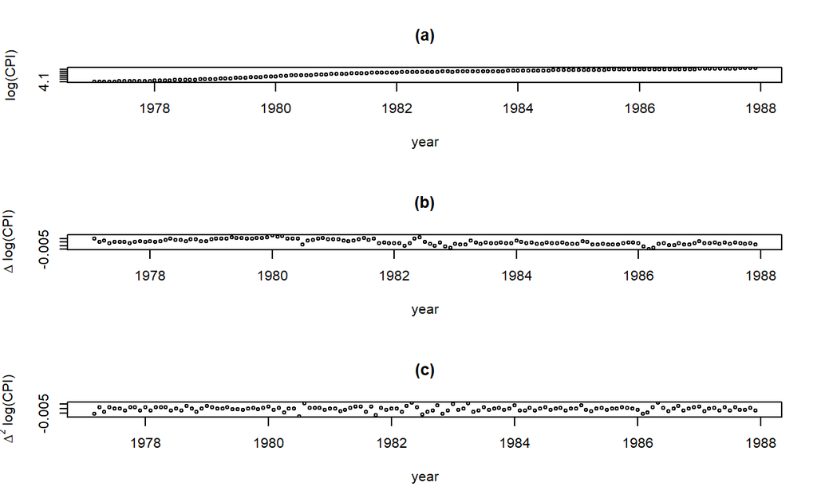

```r
par(mfrow=c(3, 1))                               # 3개의 그래프를 한 화면에 출력
plot(ts(log(CPI),                                # log(CPI)를 ts로 변환
        start = c(1977, 1),                      # 시계열의 시작 날짜 / c(1977, 1) : 1977년 1월
        frequency = 12),                         # 주기 / 12 : 월별 시계열로 1년에 12번 관측
     xlab = "year", ylab = "log(CPI)",           # 축 이름
     type = "b",                                 # 점과 선을 함께 표시
     main = "(a)")                               # 제목
plot(ts(as.vector(CPI_diff1),                    # log(CPI)를 1번 차분한 시계열을 ts로 변환
        start = c(1977, 2),                      # 시계열의 시작 날짜 / c(1977, 2) : 1977년 2월
        frequency = 12),
     xlab = "year", ylab = expression(paste(Delta," log(CPI)")),
     type = "b",
     main = "(b)")
plot(ts(as.vector(CPI_diff2),                    # log(CPI)를 2번 차분한 시계열을 ts로 변환
        start = c(1977, 3),                      # 시계열의 시작 날짜 / c(1977, 3) : 1977년 3월
        frequency = 12),
     xlab ="year", ylab = expression(paste(Delta^2," log(CPI)")),
     type = "b",
     main = "(c)")
```

`Caution!` 함수 `ts()`를 이용하여 시계열 객체로 변환할 수 있으며, 옵션 `start`에는 시계열의 시작 날짜, 옵션 `frequency`에는 주기를 입력한다.  
`Result!` (a) 그래프를 통해 원 시계열 log(CPI)는 Momentum 현상을 보인다는 것을 알 수 있다.  
(b) 그래프를 통해 1번 차분한 log(CPI)는 Momentum 현상은 보이지 않으나, 시간이 흐름에 따라 평균이 변한다는 것을 알 수 있다.  
(c) 그래프를 통해 2번 차분한 log(CPI)는 시간이 흐름에 따라 평균이 0에서 변하지 않는다는 것을 알 수 있다.

## **3-1. ARIMA 모형**

```r
# 2번 차분한 log(CPI)에 MA(2) 모형 구축
fit_ma <- arima(CPI_diff2,
                order = c(0, 0, 2))              # (p, d, q)

fit_ma
```

```
Call:
arima(x = CPI_diff2, order = c(0, 0, 2))

Coefficients:
          ma1      ma2  intercept
      -0.3433  -0.3694      0e+00
s.e.   0.0831   0.0837      1e-04

sigma^2 estimated as 5.062e-06:  log likelihood = 607.81,  aic = -1207.62
```

`Result!` 2번 차분한 log(CPI)에 대해 구축된 MA(2) 모형, 즉, 원 시계열 log(CPI)에 대해 구축된 ARIMA(0,2,2) 모형은 $(1-B)^2Y_t=\epsilon_t-0.3433\epsilon_{t-1}-0.3694\epsilon_{t-2}$이다.

```r
# 잔차를 이용한 모형 진단
Box.test(fit_ma$resid,                           # 잔차
         lag = 20,
         type = "Ljung-Box",
         fitdf = 2)                              # 추정된 theta 개수
```

```
    Box-Ljung test

data:  fit_ma$resid
X-squared = 26.956, df = 18, p-value = 0.07983
```

`Result!` 귀무가설 $H_0 : \rho(1)=\rho(2)=\cdots=\rho(20)=0$에 대한 검정 결과에 따르면, $p$값이 0.07983이므로 유의수준 0.05에서 $p$값이 0.05보다 크기 때문에 귀무가설을 기각하지 못한다. 즉, 잔차에 대해 시차 20까지의 자기상관계수 $\rho(1), \rho(2), \cdots, \rho(20)$ 중 유의한 자기상관계수가 적어도 1개 존재한다는 증거가 부족하며, 2번 차분한 log(CPI)에 대해 MA(2) 모형을 가정하는 것이 적절하다.

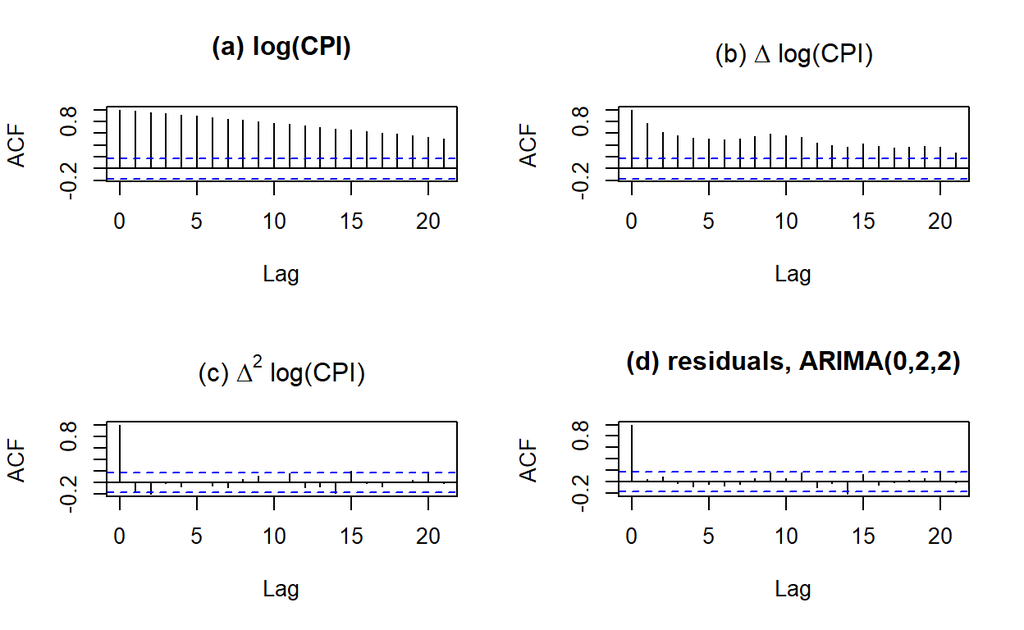

```r
par(mfrow=c(2,2))                                # 1행에 2개의 그래프를 출력 -> 총 2개의 행으로 4개의 그래프가 출력됨
acf(log(CPI),main = "(a) log(CPI)")
acf(CPI_diff1, main = expression(paste("(b) ",Delta," log(CPI)")))
acf(CPI_diff2, main = expression(paste("(c) ",Delta^2," log(CPI)")))
acf(fit_ma$resid, main = "(d) residuals, ARIMA(0,2,2)")
```

`Result!` (a) 그래프를 통해 원 시계열 log(CPI)의 자기상관계수 ACF는 천천히 감소하고 있다는 것을 알 수 있으며, 이는 원 시계열이 비정상시계열임을 의미한다.  
(c) 그래프를 통해 2번 차분한 log(CPI)의 자기상관계수 ACF는 처음 2개의 시차에서 큰 자기상관을 가지고, 그 이후는 작은 자기상관을 가진다는 것을 알 수 있다.  
(d) 그래프를 통해 2번 차분한 log(CPI)에 구축된 MA(2) 모형의 잔차는 자기상관이 존재하지 않다는 것을 알 수 있다. 이는 2번 차분한 log(CPI)에 MA(2) 모형, 즉, 원 시계열 log(CPI)에 ARIMA(0,2,2) 모형을 가정하는 것이 적절하다는 것을 의미한다.

# **4. Mishkin 데이터셋**

Package `"Ecdat"`에서 제공하는 Mishkin 데이터셋은 1950년 2월부터 1990년 12월 사이에 인플레이션율에 대한 시계열 데이터셋이다.

```r
# 패키지 설치
pacman::p_load("Ecdat")

# 데이터 불러오기
data(Mishkin, package = "Ecdat")
y <- as.vector(Mishkin[,1])             # 월별 인플레이션율 추출
y
```

```
  [1] -3.552289  5.247540  1.692860  5.064298  6.719322 11.668920
  [7]  9.912501  8.346786  6.517766  4.865085 16.076321 19.154240
 [13] 14.061910  4.650814  1.546310  4.627010 -1.540355  1.540355
 [19]  0.000000  7.672257  6.102576  6.209472  4.533152  0.000000
 [25] -7.564866  0.000000 19.570490 -1.494151  1.494151  0.000000
 [31] -1.494151  0.000000  1.494151  0.000000 -1.494151 -2.993894
 [37] -6.010291  3.008908  1.501630  2.997634  4.482457  2.979029
 [43]  2.971549  1.483071  2.960655 -4.443726 -1.484906  2.967978
 [49] -1.483071 -1.484906 -2.839906  2.839906  1.484906  0.000000
 [55] -1.484906 -2.839906 -2.982291  2.982291 -2.982291  0.000000
 [61]  0.000000  1.492020  0.000000  0.000000  0.000000  2.978693
 [67] -2.978693  4.330177  0.000000  1.484906 -2.836390  0.000000
 [73]  0.000000  2.836390  1.483071  5.914023  5.751562  8.774637
 [79] -1.457907  1.457907  5.682521  1.449363  2.893485  0.000000
 [85]  2.886525  2.748830  2.873018  2.866156  7.006195  5.678584
```

[output cut: 67 more lines]

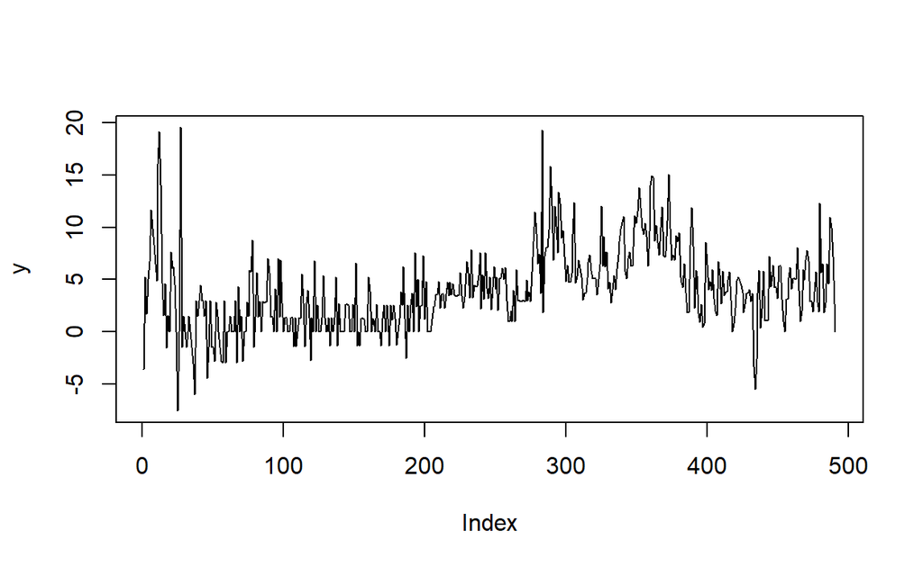

```r
# 시계열 그림
plot(y, type = "l")
```

`Result!` 시간의 흐름에 따라 평균이 변하므로 원 시계열은 비정상시계열임이 의심된다.

## **4-1. 단위근 검정**

```r
# 패키지 설치
pacman::p_load("tseries")

# Dickey-Fuller test
adf.test(y)
```

```
    Augmented Dickey-Fuller Test

data:  y
Dickey-Fuller = -3.8651, Lag order = 7, p-value = 0.01576
alternative hypothesis: stationary
```

```r
# Phillips-Perron test
pp.test(y)
```

```
    Phillips-Perron Unit Root Test

data:  y
Dickey-Fuller Z(alpha) = -248.75, Truncation lag parameter =
5, p-value = 0.01
alternative hypothesis: stationary
```

```r
# KPSS test
kpss.test(y)
```

```
    KPSS Test for Level Stationarity

data:  y
KPSS Level = 2.51, Truncation lag parameter = 5, p-value =
0.01
```

`Caution!` 단위근 검정을 수행하기 위해 Package `"tseries"`에서 제공하는 함수 `adf.test()`, `pp.test()`, `kpss.test()`를 사용한다.  
`Result!` 1. Dickey-Fuller test를 수행했을 때, $p$값이 0.01576이므로 유의수준 0.05에서 $p$값이 0.05보다 작기 때문에 귀무가설을 기각한다. 즉, 관측된 시계열은 정상성을 만족한다.  
2. Phillips-Perron test를 수행했을 때, $p$값이 0.01이므로 유의수준 0.05에서 $p$값이 0.05보다 작기 때문에 귀무가설을 기각한다. 즉, 관측된 시계열은 정상성을 만족한다.  
3. KPSS test를 수행했을 때, $p$값이 0.01이므로 유의수준 0.05에서 $p$값이 0.05보다 작기 때문에 귀무가설을 기각한다. 즉, 단위근이 존재하므로 관측된 시계열은 비정상성을 가진다.

## **4-2. ARIMA 모형 구축**

```r
# 패키지 설치
pacman::p_load("forecast")

auto.arima(y,
           max.p = 5, max.q = 5,
           ic = "bic")              # BIC 기준으로 BIC가 가장 작은 모형을 최적 모형으로 선택
```

```
Series: y
ARIMA(1,1,1)

Coefficients:
         ar1      ma1
      0.2383  -0.8772
s.e.  0.0550   0.0269

sigma^2 = 8.587:  log likelihood = -1221.62
AIC=2449.25   AICc=2449.29   BIC=2461.83
```

```r
# ARIMA(1,1,1) 모형 구축
fitARIMA111 <- arima(y, c(1, 1, 1))
```

`Result!` 함수 `auto.arima()`를 이용하여 BIC 기준으로 최적의 모형을 판단했을 때, ARIMA(1,1,1) 모형이 선택되었다. 추정된 모수 결과를 이용하면 구축된 ARIMA(1,1,1) 모형은 $(1-B)Y_t = 0.2383Y_{t-1}+\epsilon_t -0.8772\epsilon_{t-1}$이다.

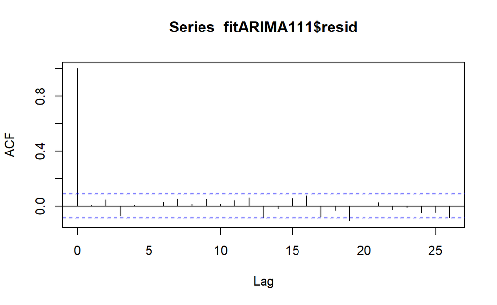

```r
# 잔차를 이용한 모형 진단
par(mfrow=c(1,1))
acf(fitARIMA111$resid)
```

```r
Box.test(fitARIMA111$resid,
         lag = 15,
         fitdf = 2)                # 추정한 phi와 theta 개수
```

```
    Box-Pierce test

data:  fitARIMA111$resid
X-squared = 14.442, df = 13, p-value = 0.3435
```

## **4-3. 예측**

```r
pred <- forecast(fitARIMA111,
                 h = 100)          # 미래 100시점까지 예측
pred
```

```
    Point Forecast       Lo 80     Hi 80     Lo 95     Hi 95
492       3.706101 -0.04167452  7.453876 -2.025627  9.437828
493       4.589298  0.60462429  8.573972 -1.504735 10.683331
494       4.799773  0.73892466  8.860620 -1.410758 11.010303
495       4.849930  0.73788314  8.961978 -1.438903 11.138764
496       4.861884  0.70417897  9.019588 -1.496777 11.220544
497       4.864732  0.66298827  9.066476 -1.561281 11.290745
498       4.865411  0.62034731  9.110475 -1.626854 11.357676
499       4.865573  0.57768877  9.153457 -1.692180 11.423325
500       4.865611  0.53534501  9.195878 -1.756959 11.488182
501       4.865620  0.49338614  9.237855 -1.821135 11.552376
502       4.865623  0.45182011  9.279425 -1.884706 11.615951
503       4.865623  0.41064046  9.320606 -1.947685 11.678931
504       4.865623  0.36983763  9.361409 -2.010088 11.741334
505       4.865623  0.32940172  9.401845 -2.071929 11.803176
```

[output cut: 86 more lines]

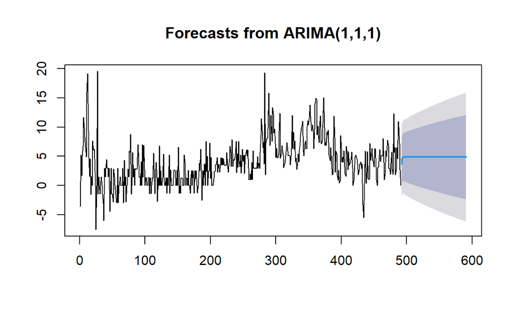

```r
plot(pred)
```

`Caution!` 예측은 Package `"forecast"`에서 제공하는 함수 `forecast()`를 이용하여 수행할 수 있다.  
`Result!` 원 시계열은 비정상성을 가지기 때문에 예측 구간은 발산한다는 것을 알 수 있다.

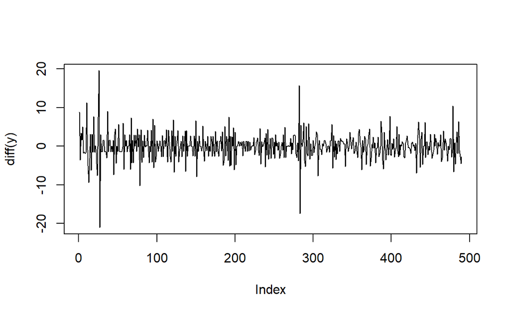

```r
# 1번 차분한 시계열에 대한 예측
## 시계열 그림
plot(diff(y), type = "l")
```

`Result!` 1번 차분한 시계열은 시간의 흐름에 따라 평균이 변하지 않고 분산도 일정해 보이므로 정상시계열로 보인다.

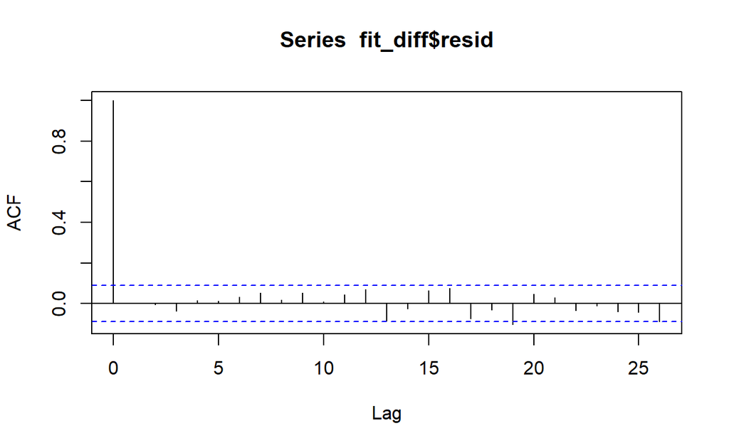

```r
# 1번 차분한 시계열에 MA(3) 모형 구축
fit_diff <- arima(diff(y),
                  order = c(0, 0, 3))

# 잔차를 이용한 모형 진단
acf(fit_diff$resid)
```

```r
Box.test(fit_diff$resid,
         lag = 15,
         fitdf = 3)
```

```
    Box-Pierce test

data:  fit_diff$resid
X-squared = 13.346, df = 12, p-value = 0.3444
```

```r
# 예측
pred.diff <- forecast(fit_diff,
                      h = 100)          # 미래 100시점까지 예측
pred.diff
```

```
    Point Forecast      Lo 80    Hi 80     Lo 95    Hi 95
491   3.4279770957 -0.3093655 7.165320 -2.287795 9.143749
492   0.8929253001 -3.5301468 5.315997 -5.871580 7.657430
493   0.5146289502 -3.9250766 4.954335 -6.275315 7.304573
494  -0.0001564659 -4.4582307 4.457918 -6.818193 6.817880
495  -0.0001564659 -4.4582307 4.457918 -6.818193 6.817880
496  -0.0001564659 -4.4582307 4.457918 -6.818193 6.817880
497  -0.0001564659 -4.4582307 4.457918 -6.818193 6.817880
498  -0.0001564659 -4.4582307 4.457918 -6.818193 6.817880
499  -0.0001564659 -4.4582307 4.457918 -6.818193 6.817880
500  -0.0001564659 -4.4582307 4.457918 -6.818193 6.817880
501  -0.0001564659 -4.4582307 4.457918 -6.818193 6.817880
502  -0.0001564659 -4.4582307 4.457918 -6.818193 6.817880
503  -0.0001564659 -4.4582307 4.457918 -6.818193 6.817880
504  -0.0001564659 -4.4582307 4.457918 -6.818193 6.817880
```

[output cut: 86 more lines]

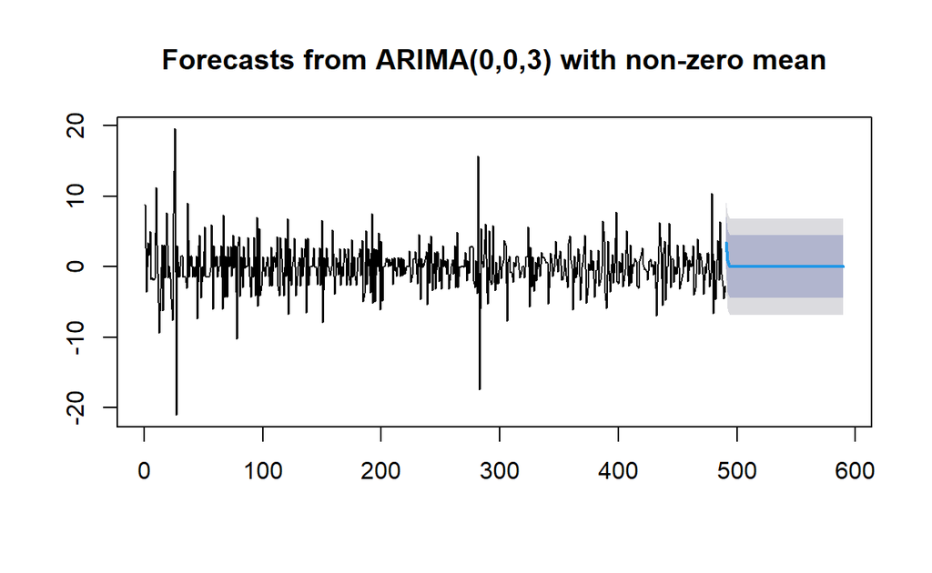

```r
plot(pred.diff)
```

`Result!` 원 시계열을 1번 차분한 시계열은 정상성을 가지기 때문에 예측 구간은 수렴한다는 것을 알 수 있다.